# tbx5_analysis_II_tmp

## Homology determination between *Mus musculus* and *Danio rerio* analysis

### Introduction

This part of the work describes the analysis that was performed to determine whether the search of synteny blocks is a suitable method that is used to evaluate homology between *Mus musculus* and *Danio rerio* genomes.

The main purpose of the analysis was to determine the similarity between the genomes by using various bioinformatical tools in order to identify synteny blocks between aforementioned organisms.

- The samples that were used in the analysis are described in the previous analysis and can be viewed here.
- The results of the Tbx5 transcription factor abundance in *Mus musculus* organism analysis can be found here.

```r
# nolint start
# Reading a file that describes synteny between organisms:
synteny_blocks <- read.csv(paste0(INTER_FILES, "synteny_blocks.csv"), skip = 1)
samples <- read.csv(file = paste0(INTER_FILES, "sample_key.csv"))

# Mouse vs. Zebrafish
# Getting synteny block positions and chromosome number for mouse:
synteny_chr_pos <<- synteny_blocks[, c(7:8, 6, 3:4, 2)]
colnames(synteny_chr_pos) <- c("startpos_MM", "endpos_MM", "chr_MM",
                                "startpos_DR", "endpos_DR", "chr_DR")

# Creating a dataframe that stores data:
df_mm <- data.frame(chr = paste0("chr", c(synteny_chr_pos[, 3])),
                    start = c(synteny_chr_pos[, 1]),
                    end = c(synteny_chr_pos[, 2]), strand = "+")

# Checking whether the starting region position is bigger than end position:
for (i in 1:length(rownames(df_mm))) {
    if (df_mm[i, 2] > df_mm[i, 3]) {
        reverse1 = df_mm[i, 2]
        df_mm[i, 2] = df_mm[i, 3]
        df_mm[i, 3] = reverse1
        df_mm[i, 4] <- "-"
    }
}

# Creating a GRanges object for created dataframe (GRange object for
# synteny blocks):
syn_grange <- makeGRangesFromDataFrame(df_mm)

# Reading bigBed files:
bbfiles <- list.files(path = paste0(INPUTS, "BigBed/"), "*bb")
grl <- GRangesList()

# Declaring what chromosomes are analyzed:
chr_abr <- c(paste0("chr", 1:19), "chrX", "chrY")

# Creating GRanges objects and extracting certain chromosomes:
for (i in 1:length(bbfiles)) {
    grl[[i]] <- import(paste0(paste0(INPUTS, "BigBed/"), bbfiles[i])) %>%
                       dplyr::filter(seqnames %in% chr_abr)
    names(grl)[i] <- samples$Graph_names[samples$Filename == bbfiles[i]]
}
# nolint end
```

### Synteny blocks by chromosome in *Mus musculus*

The barchart bellow shows how many fragments in each *Mus musculus* chromosome belong to synteny blocks.

[figure not shown]

```r
# nolint start
plot0 <- ggplot(chr_syn, aes(x = Chr, y = Freq)) +
    geom_bar(width = 0.8, size = 0.2, fill = "#be800d", color = "#523a0f",
             stat = 'identity', position = position_dodge(0.5)) +
    geom_text(aes(label = Freq), colour = colours, vjust = -0.2, hjust = 0.5,
              size = sizes, fontface = bold) +
    labs(title = "", x = "", y = "") +
    ylim(0, 2.5) +
    scale_y_continuous(labels = label_number(suffix = " K", scale = 1e-2)) +
    theme(panel.background = element_rect(fill = "#eeeef1",
                                          colour = "#4c0001"),
          panel.grid.major.y = element_line(colour = "#cab5b5", size = 0.3,
                                            linetype = "dashed"),
          panel.grid.minor.y = element_line(colour = "#cab5b5", size = 0.3,
                                            linetype = "dashed"),
          panel.grid.major.x = element_line(colour = "#cab5b5", size = 0.2,
                                            linetype = "longdash"),
          panel.grid.minor.x = element_line(colour = "#cab5b5", size = 0.2,
                                            linetype = "longdash"),
          axis.text.x = element_text(angle = 45, hjust = 1, vjust = 1, size = 11,
                                     face = "bold", color = "black"),
          axis.text.y = element_text(size = 11, face = "bold", color = "black"),
          axis.title.x = element_text(size = 2),
          axis.title.y = element_text(size = 16),
          plot.title = element_text(hjust = 0.5, face = "bold"),
          legend.title = element_text(face = "bold", size = 10),
          legend.text = element_text(size = 10))

# png(file = paste0(FIGURES, "Synteny_Chr_MM.png"))
# plot0
# dev.off()
plot0
```

```r
# nolint end
```

As it can be seen from the diagram the greatest number of fragments has been detected in the 1, 2 and 11 chromosomes (104, 132 and 112 fragments, respectively). The smallest number of fragments has been detected in the 18th chromosome (39 fragments).

### Synteny blocks by chromosome in *Danio rerio*

The barchart bellow shows how many fragments in each *Danio rerio* chromosome belong to synteny blocks.

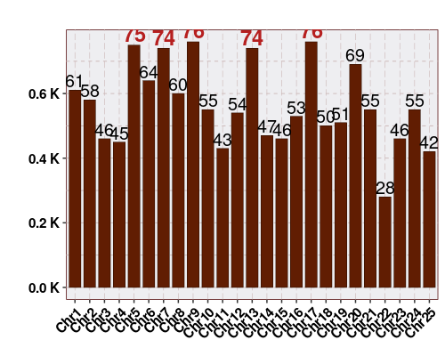

```r
# nolint start
plot1 <- ggplot(chr_syn, aes(x = Chr, y = Freq)) +
    geom_bar(width = 0.8, size = 0.2, fill = "#611d02", color = "#310f01",
             stat = 'identity', position = position_dodge(0.5)) +
    geom_text(aes(label = Freq), colour = colours, vjust = -0.2, hjust = 0.5,
              size = sizes, fontface = bold) +
    labs(title = "", x = "", y = "") +
    ylim(0, 2.5) +
    scale_y_continuous(labels = label_number(suffix = " K", scale = 1e-2)) +
    theme(panel.background = element_rect(fill = "#eeeef1",
                                          colour = "#4c0001"),
          panel.grid.major.y = element_line(colour = "#cab5b5", size = 0.3,
                                            linetype = "dashed"),
          panel.grid.minor.y = element_line(colour = "#cab5b5", size = 0.3,
                                            linetype = "dashed"),
          panel.grid.major.x = element_line(colour = "#cab5b5", size = 0.2,
                                            linetype = "longdash"),
          panel.grid.minor.x = element_line(colour = "#cab5b5", size = 0.2,
                                            linetype = "longdash"),
          axis.text.x = element_text(angle = 45, hjust = 1, vjust = 1,
                                     size = 11, face = "bold",
                                     color = "black"),
          axis.text.y = element_text(size = 11, face = "bold",
                                     color = "black"),
          axis.title.x = element_text(size = 2),
          axis.title.y = element_text(size = 16),
          plot.title = element_text(hjust = 0.5, face = "bold"),
          legend.title = element_text(face = "bold", size = 10),
          legend.text = element_text(size = 10))

# png(file = paste0(FIGURES, "Synteny_Chr_DR.png"))
# plot1
# dev.off()
plot1
```

```r
# nolint end
```

### Sample peaks percentage in synteny blocks

It can be seen in the horizontal barchart below that overall percentage of the sample peaks in synteny blocks did not exceed 35%.

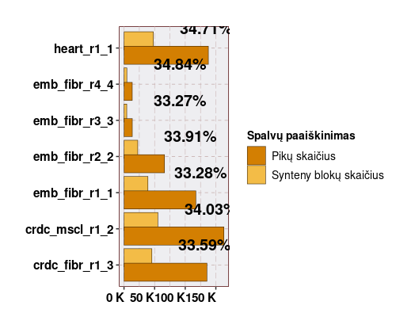

```r
# nolint start
plot2 <- ggplot(df_final, aes(fill = indic, y = as.numeric(value), x = names)) +
    geom_bar(width = 1, size = 0.2, colour = "#3f2704", stat = 'identity',
             position = position_dodge(0.8)) +
    geom_text(aes(label = ifelse(indic == "synteny_overlaps",
                                 paste0(round(as.numeric(percentage),
                                              digits = 2), "%"), ""),
              fontface = 2), vjust = -1.2, hjust = -0.5, size = 5) +
    labs(title = "", x = "", y = "") +
    scale_fill_manual(values = c("#d37f02", "#f3bc47"),
                      labels = c("Pikų skaičius", "Synteny blokų skaičius")) +
    scale_y_continuous(labels = label_number(suffix = " K", scale = 1e-3)) +
    guides(fill = guide_legend(title = "Spalvų paaiškinimas")) +
    theme(panel.background = element_rect(fill = "#eeeef1",
                                          colour = "#4c0001"),
          panel.grid.major.y = element_line(colour = "#cab5b5", size = 0.3,
                                            linetype = "dashed"),
          panel.grid.minor.y = element_line(colour = "#cab5b5", size = 0.3,
                                            linetype = "dashed"),
          panel.grid.major.x = element_line(colour = "#cab5b5", size = 0.2,
                                            linetype = "longdash"),
          panel.grid.minor.x = element_line(colour = "#cab5b5", size = 0.2,
                                            linetype = "longdash"),
          axis.text.x = element_text(angle = 0, hjust = 1, vjust = 1, size = 11,
                                     face = "bold", color = "black"),
          axis.text.y = element_text(size = 11, face = "bold",
                                     color = "black"),
          axis.title.x = element_text(size = 2),
          axis.title.y = element_text(size = 16),
          plot.title = element_text(hjust = 0.5, face = "bold"),
          legend.title = element_text(face = "bold", size = 10),
          legend.text = element_text(size = 10)) +
    coord_flip()

# png(file = paste0(FIGURES, "Synteny_blocks_peaks.png"))
# plot2
# dev.off()
plot2
```

```r
# nolint end
```

### Peak annotation

[output not shown]

A diagram that shows how many unique genes were identified for each sample belonging to the synteny block.

[figure not shown]

```r
# nolint start
genes_samples <- data.frame(matrix(ncol = 3, nrow = 0))
colnames(genes_samples) <- c("Sample", "Gene_count", "Percentage")

for (smpl in 1:length(grl_synteny)) {
    genes_tot <- length(unique(grl_synteny[[smpl]]$gene_symbol))

    row = c(names(grl_synteny[smpl]),
            genes_tot, (genes_tot / length(genes(mm_known_genes))) * 100)
    genes_samples[nrow(genes_samples) + 1, ] <- row
}

# Diagram that shows how many unique genes were identified for each
# sample belonging to the synteny block:
plot3 <- ggplot(genes_samples, aes(x = Sample, y = as.numeric(Percentage))) +
    geom_bar(stat = "identity", fill = "#cc8b12",
             width = .5, color = "#8d5c00") +
    labs(title = "", x = "", y = "Anotuotų pikų % M. musculus") +
    geom_text(aes(label = paste0(round(as.numeric(Percentage), digit = 2), "%")),
              color = "#030101", size = 5, vjust = -1, fontface = 2) +
    coord_cartesian(ylim = c(0, as.numeric(max(genes_samples$Percentage)) + 20)) +
    theme(axis.text = element_text(size = 10, colour = "black"),
          axis.text.x = element_text(angle = 45, hjust = 1, size = 12,
                                     vjust = 1, face = "bold"),
          axis.text.y = element_text(size = 12, face = "bold"),
          axis.title.x = element_text(size = 14, colour = "black"),
          axis.title.y = element_text(size = 14, colour = "black"),
          panel.grid.major = element_line(color = "#eeeeee"),
          plot.title = element_text(hjust = 0.5, size = 16, face = "bold"),
          panel.background = element_rect(fill = "#eeeef1", colour = "#3a1010"),
          panel.grid.major.y = element_line(colour = "#cab5b5",
                                            size = 0.3, linetype = "dashed"),
          panel.grid.minor.y = element_line(colour = "#cab5b5",
                                            size = 0.3, linetype = "dashed"),
          panel.grid.major.x = element_line(colour = "#cab5b5",
                                            size = 0.2, linetype = "longdash"),
          panel.grid.minor.x = element_line(colour = "#cab5b5",
                                            size = 0.2, linetype = "longdash"),
          legend.position = c(0.777, 0.788))

# png(file = paste0(FIGURES, "Unique_genes_MM.png"))
# plot3
# dev.off()
plot3
```

```r
# nolint end
```

A diagram that shows how many unique genes were identified for each sample belonging to the synteny block.

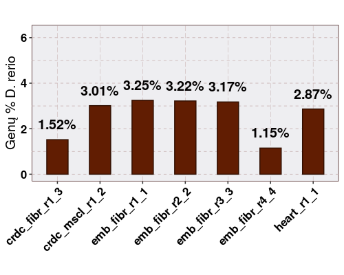

```r
plot4 <- ggplot(genes_synteny, aes(x = Sample, y = as.numeric(Percentage))) +
    geom_bar(stat = "identity", fill = "#611d02",
            width = .5, color = "#310f01") +
    labs(title = "", x = "", y = "Genų % D. rerio") +
    geom_text(aes(label = paste0(round(as.numeric(Percentage), digit = 2), "%")),
              color = "#030101", size = 5, vjust = -1, fontface = 2) +
    coord_cartesian(ylim = c(0, as.numeric(max(genes_synteny$Percentage)) + 3)) +
    theme(axis.text = element_text(size = 10, colour = "black"),
          axis.text.x = element_text(angle = 45, hjust = 1, size = 12,
                                     vjust = 1, face = "bold"),
          axis.text.y = element_text(size = 12, face = "bold"),
          axis.title.x = element_text(size = 14, colour = "black"),
          axis.title.y = element_text(size = 14, colour = "black"),
          panel.grid.major = element_line(color = "#eeeeee"),
          plot.title = element_text(hjust = 0.5, size = 16, face = "bold"),
          panel.background = element_rect(fill = "#eeeef1", colour = "#3a1010"),
          panel.grid.major.y = element_line(colour = "#cab5b5",
                                            size = 0.3, linetype = "dashed"),
          panel.grid.minor.y = element_line(colour = "#cab5b5",
                                            size = 0.3, linetype = "dashed"),
          panel.grid.major.x = element_line(colour = "#cab5b5",
                                            size = 0.2, linetype = "longdash"),
          panel.grid.minor.x = element_line(colour = "#cab5b5",
                                            size = 0.2, linetype = "longdash"),
          legend.position = c(0.777, 0.788))

# png(file = paste0(FIGURES, "Unique_genes_DR.png"))
# plot4
# dev.off()
plot4
```

```r
# nolint end
```

[output not shown]

[figure not shown]

```r
# nolint start
# Creating a list that stores ggplot objects:
plots <- list()
for (smpl in 1:length(grl_mm)) {

    remove_y <- theme(
        axis.text.y = element_blank(),
        axis.ticks.y = element_blank(),
        axis.title.y = element_blank())

        plots[[smpl]] <- find_common_genes(grl_mm[[smpl]],
                                           names(grl_mm[smpl])) + remove_y
}

# png(file = paste0(FIGURES, "PWM_matches_all.png"), width = 1200)
# ggarrange(plotlist = plots, nrow = 1, common.legend = TRUE, widths = 5,
#           legend = "bottom")
# dev.off()
ggarrange(plotlist = plots, nrow = 1, common.legend = TRUE, widths = 5,
          legend = "bottom")
```

```r
# nolint end
```

**Click to see page metadata**

Computation Started: `2023-02-11 21:36:04`

Finished in `7.662 mins`

**Git Log**

No git history available for this page

**Packages**

[output not shown]

[output cut: 151 more lines]

**System Information**

|  | systemInfo |
| --- | --- |
| version | R version 4.2.2 Patched (2022-11-10 r83330) |
| platform | x86_64-pc-linux-gnu (64-bit) |
| locale | lt_LT.utf8 |
| OS | Linux Mint 20.3 |
| UI | X11 |

**Scikick Configuration**

```bash
cat scikick.yml
```

```
### Scikick Project Workflow Configuration File

# Directory where Scikick will store all standard notebook outputs
reportdir: report

# --- Content below here is best modified by using the Scikick CLI ---

# Notebook Execution Configuration (format summarized below)
# analysis:
#  first_notebook.Rmd:
#  second_notebook.Rmd:
#  - first_notebook.Rmd     # must execute before second_notebook.Rmd
#  - functions.R            # file is used by second_notebook.Rmd
#
# Each analysis item is executed to generate md and html files, E.g.:
# 1. <reportdir>/out_md/first_notebook.md
# 2. <reportdir>/out_html/first_notebook.html
analysis: !!omap
- tbx5_analysis_II.Rmd:
version_info:
  snakemake: 7.0.0
  ruamel.yaml: 0.17.21
  scikick: 0.2.0
```

**Functions**